# Guide to SuperLearner

# 12 Weight distribution for SuperLearner

The weights or coefficients of the SuperLearner are stochastic - they will change as the data changes. So we don’t necessarily trust a given set of weights as being the “true” weights, but when we use CV.SuperLearner we at least have multiple samples from the distribution of the weights.

We can write a little function to extract the weights at each CV.SuperLearner iteration and summarize the distribution of those weights. This may be added to the SuperLearner package sometime in the future.

```r
# Review meta-weights (coefficients) from a CV.SuperLearner object
review_weights = function(cv_sl) {
  meta_weights = coef(cv_sl)
  means = colMeans(meta_weights)
  sds = apply(meta_weights, MARGIN = 2,  FUN = sd)
  mins = apply(meta_weights, MARGIN = 2, FUN = min)
  maxs = apply(meta_weights, MARGIN = 2, FUN = max)
  # Combine the stats into a single matrix.
  sl_stats = cbind("mean(weight)" = means, "sd" = sds, "min" = mins, "max" = maxs)
  # Sort by decreasing mean weight.
  sl_stats[order(sl_stats[, 1], decreasing = TRUE), ]
}

print(review_weights(cv_sl), digits = 3)
```

```
##                 mean(weight)    sd     min   max
## SL.ranger_3_All        0.504 0.497 0.00000 0.994
## SL.glmnet_All          0.302 0.258 0.00643 0.483
## SL.ranger_All          0.194 0.336 0.00000 0.582
## SL.mean_All            0.000 0.000 0.00000 0.000
## SL.ranger_1_All        0.000 0.000 0.00000 0.000
## SL.ranger_2_All        0.000 0.000 0.00000 0.000
```

We recommend reviewing the weight distribution for any SuperLearner project to better understand which algorithms are chosen for the ensemble.

# 13 Feature selection (screening)

When datasets have many covariates our algorithms may benefit from first choosing a subset of available covariates, a step called **feature selection**. Then we pass only those variables to the modeling algorithm, and it may be less likely to overfit to variables that are not related to the outcome.

Let’s revisit `listWrappers()` and check out the bottom section.

```r
listWrappers()
```

```
## All prediction algorithm wrappers in SuperLearner:
```

```
##  [1] "SL.bartMachine"      "SL.bayesglm"         "SL.biglasso"
##  [4] "SL.caret"            "SL.caret.rpart"      "SL.cforest"
##  [7] "SL.earth"            "SL.gam"              "SL.gbm"
## [10] "SL.glm"              "SL.glm.interaction"  "SL.glmnet"
## [13] "SL.ipredbagg"        "SL.kernelKnn"        "SL.knn"
## [16] "SL.ksvm"             "SL.lda"              "SL.leekasso"
## [19] "SL.lm"               "SL.loess"            "SL.logreg"
## [22] "SL.mean"             "SL.nnet"             "SL.nnls"
## [25] "SL.polymars"         "SL.qda"              "SL.randomForest"
## [28] "SL.ranger"           "SL.ridge"            "SL.rpart"
## [31] "SL.rpartPrune"       "SL.speedglm"         "SL.speedlm"
## [34] "SL.step"             "SL.step.forward"     "SL.step.interaction"
## [37] "SL.stepAIC"          "SL.svm"              "SL.template"
## [40] "SL.xgboost"
```

```
##
## All screening algorithm wrappers in SuperLearner:
```

```
## [1] "All"
## [1] "screen.SIS"            "screen.corP"           "screen.corRank"
## [4] "screen.glmnet"         "screen.randomForest"   "screen.template"
## [7] "screen.ttest"          "write.screen.template"
```

```r
# Review code for corP, which is based on univariate correlation.
screen.corP
```

```
## function (Y, X, family, obsWeights, id, method = "pearson", minPvalue = 0.1,
##     minscreen = 2, ...)
## {
##     listp <- apply(X, 2, function(x, Y, method) {
##         ifelse(var(x) <= 0, 1, cor.test(x, y = Y, method = method)$p.value)
##     }, Y = Y, method = method)
##     whichVariable <- (listp <= minPvalue)
##     if (sum(whichVariable) < minscreen) {
##         warning("number of variables with p value less than minPvalue is less than minscreen")
##         whichVariable[rank(listp) <= minscreen] <- TRUE
##     }
##     return(whichVariable)
## }
## <bytecode: 0x146dcc790>
## <environment: namespace:SuperLearner>
```

```r
set.seed(1)

# Fit the SuperLearner.
# We need to use list() instead of c().
cv_sl = CV.SuperLearner(Y = y_train, X = x_train, family = binomial(),
                        # For a real analysis we would use V = 10.
                        V = 3,
                        parallel = "multicore",
                        SL.library = list("SL.mean", "SL.glmnet", c("SL.glmnet", "screen.corP")))
summary(cv_sl)
```

```
##
## Call:
## CV.SuperLearner(Y = y_train, X = x_train, V = 3, family = binomial(), SL.library = list("SL.mean",
##     "SL.glmnet", c("SL.glmnet", "screen.corP")), parallel = "multicore")
##
## Risk is based on: Mean Squared Error
##
## All risk estimates are based on V =  3
##
##              Algorithm     Ave        se      Min     Max
##          Super Learner 0.10463 0.0168593 0.065549 0.12602
##            Discrete SL 0.10492 0.0170909 0.066405 0.12602
##            SL.mean_All 0.24260 0.0095617 0.226900 0.26050
##          SL.glmnet_All 0.10492 0.0170909 0.066405 0.12602
##  SL.glmnet_screen.corP 0.10392 0.0163746 0.066405 0.12303
```

We see a small performance boost by first screening by univarate correlation with our outcome, and only keeping variables with a p-value less than 0.10. Try using some of the other screening algorithms as they may do even better for a particular dataset.

# 14 Optimize for AUC

For binary prediction we are typically trying to maximize AUC, which can be the best performance metric when our outcome variable has some imbalance. In other words, we don’t have exactly 50% 1s and 50% 0s in our outcome. Our SuperLearner is not targeting AUC by default, but it can if we tell it to by specifying our method.

```r
set.seed(1)

cv_sl = CV.SuperLearner(Y = y_train, X = x_train, family = binomial(),
                        # For a real analysis we would use V = 10.
                        V = 3,
                        method = "method.AUC",
                        SL.library = list("SL.mean", "SL.glmnet", c("SL.glmnet", "screen.corP")))
summary(cv_sl)
```

```
##
## Call:
## CV.SuperLearner(Y = y_train, X = x_train, V = 3, family = binomial(), SL.library = list("SL.mean",
##     "SL.glmnet", c("SL.glmnet", "screen.corP")), method = "method.AUC")
##
## Risk is based on: Area under ROC curve (AUC)
##
## All risk estimates are based on V =  3
##
##              Algorithm     Ave se     Min     Max
##          Super Learner 0.92045 NA 0.89372 0.95429
##            Discrete SL 0.91989 NA 0.89372 0.95429
##            SL.mean_All 0.50000 NA 0.50000 0.50000
##          SL.glmnet_All 0.92322 NA 0.89372 0.95429
##  SL.glmnet_screen.corP 0.91989 NA 0.89372 0.95429
```

This conveniently shows us the AUC for each algorithm without us having to calculate it manually. But we aren’t getting SEs sadly.

Another important optimizer to consider is negative log likelihood, which is intended for binary outcomes and will often work better than NNLS (the default). This is specified by method = “NNloglik”.

# 15 XGBoost hyperparameter exploration

```r
# 3 * 3 * 3 = 27 different configurations.
# For a real analysis we would do 100, 500, or 1000 trees - this is just a demo.
tune = list(ntrees = c(10, 20, 50),
            max_depth = 1:3,
            shrinkage = c(0.001, 0.01, 0.1))

# Set detailed names = T so we can see the configuration for each function.
# Also shorten the name prefix.
learners = create.Learner("SL.xgboost", tune = tune, detailed_names = TRUE, name_prefix = "xgb")

# 27 configurations - not too shabby.
length(learners$names)
```

```
## [1] 27
```

```r
learners$names
```

```
##  [1] "xgb_10_1_0.001" "xgb_20_1_0.001" "xgb_50_1_0.001" "xgb_10_2_0.001"
##  [5] "xgb_20_2_0.001" "xgb_50_2_0.001" "xgb_10_3_0.001" "xgb_20_3_0.001"
##  [9] "xgb_50_3_0.001" "xgb_10_1_0.01"  "xgb_20_1_0.01"  "xgb_50_1_0.01"
## [13] "xgb_10_2_0.01"  "xgb_20_2_0.01"  "xgb_50_2_0.01"  "xgb_10_3_0.01"
## [17] "xgb_20_3_0.01"  "xgb_50_3_0.01"  "xgb_10_1_0.1"   "xgb_20_1_0.1"
## [21] "xgb_50_1_0.1"   "xgb_10_2_0.1"   "xgb_20_2_0.1"   "xgb_50_2_0.1"
## [25] "xgb_10_3_0.1"   "xgb_20_3_0.1"   "xgb_50_3_0.1"
```

```r
# Confirm we have multiple cores configured. This should be > 1.
getOption("mc.cores")
```

```
## [1] 2
```

```r
# Remember to set multicore-compatible seed.
set.seed(1, "L'Ecuyer-CMRG")

# Fit the CV.SuperLearner.
system.time({
  cv_sl = CV.SuperLearner(Y = y_train, X = x_train, family = binomial(),
                          # For a real analysis we would use V = 10.
                          V = 3,
                          parallel = "multicore",
                          SL.library = c("SL.mean", "SL.glmnet", learners$names, "SL.ranger"))
})
```

```
##    user  system elapsed
##   2.414   0.105   4.921
```

```r
# Review results.
summary(cv_sl)
```

```
##
## Call:
## CV.SuperLearner(Y = y_train, X = x_train, V = 3, family = binomial(), SL.library = c("SL.mean",
##     "SL.glmnet", learners$names, "SL.ranger"), parallel = "multicore")
##
## Risk is based on: Mean Squared Error
##
## All risk estimates are based on V =  3
##
##           Algorithm      Ave         se      Min     Max
##       Super Learner 0.090546 0.01510607 0.052720 0.11561
##         Discrete SL 0.093214 0.01543835 0.050986 0.12535
##         SL.mean_All 0.242600 0.00956173 0.226900 0.26050
##       SL.glmnet_All 0.104150 0.01673952 0.064775 0.12535
##  xgb_10_1_0.001_All 0.247864 0.00022090 0.247406 0.24828
##  xgb_20_1_0.001_All 0.245773 0.00043925 0.244861 0.24661
##  xgb_50_1_0.001_All 0.239599 0.00103601 0.237065 0.24182
##  xgb_10_2_0.001_All 0.247864 0.00022090 0.247406 0.24828
##  xgb_20_2_0.001_All 0.245773 0.00043925 0.244861 0.24661
##  xgb_50_2_0.001_All 0.239599 0.00103601 0.237065 0.24182
##  xgb_10_3_0.001_All 0.247864 0.00022090 0.247406 0.24828
##  xgb_20_3_0.001_All 0.245773 0.00043925 0.244861 0.24661
##  xgb_50_3_0.001_All 0.239599 0.00103601 0.237065 0.24182
##   xgb_10_1_0.01_All 0.229984 0.00200462 0.224800 0.23455
##   xgb_20_1_0.01_All 0.213539 0.00380533 0.203477 0.22257
##   xgb_50_1_0.01_All 0.179899 0.00791583 0.154434 0.20141
##   xgb_10_2_0.01_All 0.229984 0.00200462 0.224800 0.23455
##   xgb_20_2_0.01_All 0.213539 0.00380533 0.203477 0.22257
##   xgb_50_2_0.01_All 0.179899 0.00791583 0.154434 0.20141
##   xgb_10_3_0.01_All 0.229984 0.00200462 0.224800 0.23455
##   xgb_20_3_0.01_All 0.213539 0.00380533 0.203477 0.22257
##   xgb_50_3_0.01_All 0.179899 0.00791583 0.154434 0.20141
##    xgb_10_1_0.1_All 0.149806 0.01102873 0.113512 0.18562
##    xgb_20_1_0.1_All 0.138650 0.01162345 0.093478 0.18195
##    xgb_50_1_0.1_All 0.139119 0.01173685 0.092681 0.18077
##    xgb_10_2_0.1_All 0.149806 0.01102873 0.113512 0.18562
##    xgb_20_2_0.1_All 0.138650 0.01162345 0.093478 0.18195
##    xgb_50_2_0.1_All 0.139119 0.01173685 0.092681 0.18077
##    xgb_10_3_0.1_All 0.149806 0.01102873 0.113512 0.18562
##    xgb_20_3_0.1_All 0.138650 0.01162345 0.093478 0.18195
##    xgb_50_3_0.1_All 0.139119 0.01173685 0.092681 0.18077
##       SL.ranger_All 0.080964 0.01228891 0.050986 0.10331
```

```r
review_weights(cv_sl)
```

```
##                    mean(weight)        sd       min       max
## SL.ranger_All         0.5635626 0.4236143 0.1540566 1.0000000
## SL.glmnet_All         0.4364374 0.4236143 0.0000000 0.8459434
## SL.mean_All           0.0000000 0.0000000 0.0000000 0.0000000
## xgb_10_1_0.001_All    0.0000000 0.0000000 0.0000000 0.0000000
## xgb_20_1_0.001_All    0.0000000 0.0000000 0.0000000 0.0000000
## xgb_50_1_0.001_All    0.0000000 0.0000000 0.0000000 0.0000000
## xgb_10_2_0.001_All    0.0000000 0.0000000 0.0000000 0.0000000
## xgb_20_2_0.001_All    0.0000000 0.0000000 0.0000000 0.0000000
## xgb_50_2_0.001_All    0.0000000 0.0000000 0.0000000 0.0000000
## xgb_10_3_0.001_All    0.0000000 0.0000000 0.0000000 0.0000000
## xgb_20_3_0.001_All    0.0000000 0.0000000 0.0000000 0.0000000
## xgb_50_3_0.001_All    0.0000000 0.0000000 0.0000000 0.0000000
## xgb_10_1_0.01_All     0.0000000 0.0000000 0.0000000 0.0000000
## xgb_20_1_0.01_All     0.0000000 0.0000000 0.0000000 0.0000000
## xgb_50_1_0.01_All     0.0000000 0.0000000 0.0000000 0.0000000
## xgb_10_2_0.01_All     0.0000000 0.0000000 0.0000000 0.0000000
## xgb_20_2_0.01_All     0.0000000 0.0000000 0.0000000 0.0000000
## xgb_50_2_0.01_All     0.0000000 0.0000000 0.0000000 0.0000000
## xgb_10_3_0.01_All     0.0000000 0.0000000 0.0000000 0.0000000
## xgb_20_3_0.01_All     0.0000000 0.0000000 0.0000000 0.0000000
## xgb_50_3_0.01_All     0.0000000 0.0000000 0.0000000 0.0000000
## xgb_10_1_0.1_All      0.0000000 0.0000000 0.0000000 0.0000000
## xgb_20_1_0.1_All      0.0000000 0.0000000 0.0000000 0.0000000
## xgb_50_1_0.1_All      0.0000000 0.0000000 0.0000000 0.0000000
## xgb_10_2_0.1_All      0.0000000 0.0000000 0.0000000 0.0000000
## xgb_20_2_0.1_All      0.0000000 0.0000000 0.0000000 0.0000000
## xgb_50_2_0.1_All      0.0000000 0.0000000 0.0000000 0.0000000
## xgb_10_3_0.1_All      0.0000000 0.0000000 0.0000000 0.0000000
## xgb_20_3_0.1_All      0.0000000 0.0000000 0.0000000 0.0000000
## xgb_50_3_0.1_All      0.0000000 0.0000000 0.0000000 0.0000000
```

We can see how stochastic the weights are for each individual execution of SuperLearner.

Finally, plot the performance for the different settings.

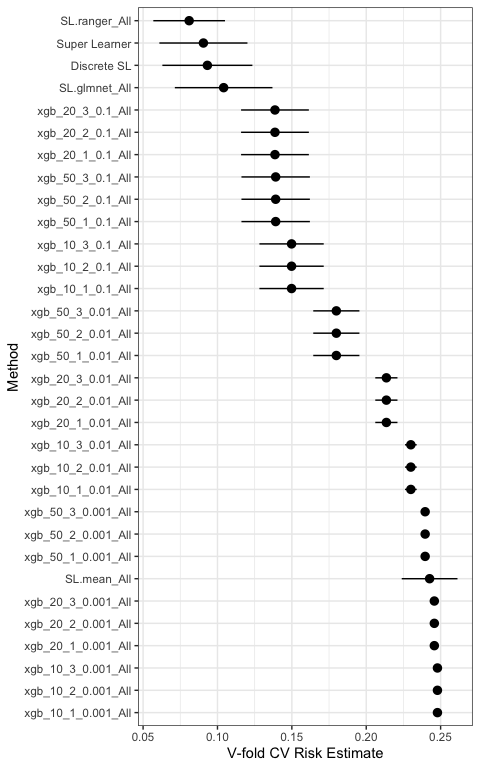

```r
plot(cv_sl) + theme_bw()
```

# 16 Troubleshooting

- If you get an error about predict for xgb.Booster, you probably need to install the latest version of XGBoost from github.

# 17 References

LeDell, E., Petersen, M., & van der Laan, M. (2015). Computationally efficient confidence intervals for cross-validated area under the ROC curve estimates. Electronic journal of statistics, 9(1), 1583.

Polley EC, van der Laan MJ (2010) Super Learner in Prediction. U.C. Berkeley Division of Biostatistics Working Paper Series. Paper 226. https://biostats.bepress.com/ucbbiostat/paper266/

van der Laan, M. J., Polley, E. C. and Hubbard, A. E. (2007) Super Learner. Statistical Applications of Genetics and Molecular Biology, 6, article 25. https://doi.org/10.2202/1544-6115.1309

van der Laan, M. J., & Rose, S. (2011). Targeted learning: causal inference for observational and experimental data. Springer Science & Business Media.